# Karls_data

Kailin

2026-03-12

# The study

The study investigates the effect of three treatments (A, B, C) on AF and PR. Potential covariates include participant age, sex, smoking status, and individual SNP genotypes encoded under an additive genetic model.

# Read in sata

The dataset (`FITFR-final-data-v3.xlsx`) contains 100 participants and 58 variables, organised into three broad categories: demographics (`age`, `sex`, `treatment`, `smoker`), genetics (51 SNP variables with the prefix `rs`), and outcome measures (`AF` and `PR`).

## Load raw data

The raw file has a two-row header: the first row contains broad category labels (“demographics”, “genetics”, “measures”) and the second row contains the actual column names. We skip the first row on read and drop the resulting category-label row and the empty leading column manually.

```r
df_raw <- read_excel(here("raw-data", "FITFR-final-data-v3.xlsx"), sheet = 1, skip = 1)

cat("Raw dimensions:", nrow(df_raw), "x", ncol(df_raw))
```

```
## Raw dimensions: 104 x 58
```

# Cleaning / Pre-processing

## · Remove junk rows

The last four rows of the file are artefacts: three fully-empty rows and one garbled header fragment. Every genuine participant has a non-missing ID, so filtering on `ID` removes them cleanly.

```r
df <- df_raw |>
  filter(!is.na(ID))

cat("Dimensions after removing junk rows:", nrow(df), "x", ncol(df))
```

```
## Dimensions after removing junk rows: 100 x 58
```

## · Check column types

Before proceeding with cleaning, we inspect the column types to verify that variables have been read in correctly and identify any that require conversion.

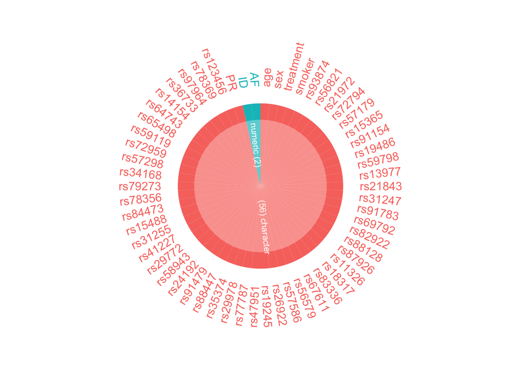

```r
# Variable Types Overview
inspect_types(df) |> show_plot()
```

```r
# Frequency distributions of the categorical variables
inspect_cat(df)
```

```
## # A tibble: 56 × 5
##    col_name   cnt common common_pcnt levels
##    <chr>    <int> <chr>        <dbl> <named list>
##  1 PR           2 yes             51 <tibble [2 × 3]>
##  2 age         22 28               9 <tibble [22 × 3]>
##  3 rs11326      3 AG              49 <tibble [3 × 3]>
##  4 rs123456     1 CC             100 <tibble [1 × 3]>
##  5 rs13977      3 CT              50 <tibble [3 × 3]>
##  6 rs14154      3 AT              57 <tibble [3 × 3]>
##  7 rs15365      3 AC              47 <tibble [3 × 3]>
##  8 rs15488      3 GT              49 <tibble [3 × 3]>
##  9 rs18317      3 GT              54 <tibble [3 × 3]>
## 10 rs19245      3 AC              53 <tibble [3 × 3]>
## # ℹ 46 more rows
```

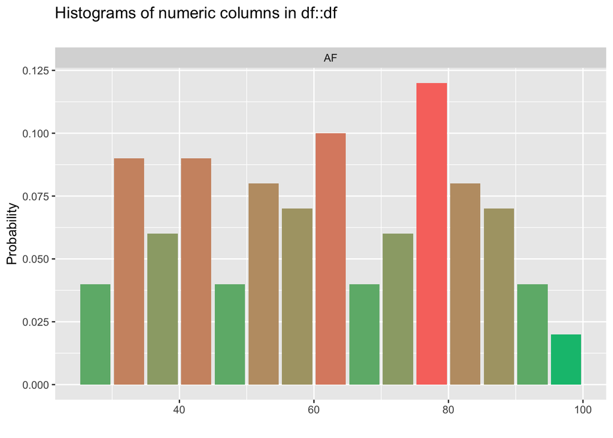

```r
# Distributions of the continuous variables
df |> select(-ID) |> inspect_num() |> show_plot()
```

The majority of columns (56) are read in as character, with only 2 numeric columns (`ID` and `AF`). This confirms that type conversion is required: `age` must be coerced to numeric, and categorical variables such as `sex`, `treatment`, `smoker`, and `PR` must be converted to factors. The SNP columns will also require some encoding under an additive genetic model.

## · Fix column types

Based on the type inspection above, `ID`, `age`, and `AF` are converted to their correct numeric types. Categorical variables are addressed in the following step.

```r
df <- df |>
  mutate(
    ID  = as.integer(ID),
    age = as.numeric(age),
    AF  = as.numeric(AF)
  )
df
```

```
## # A tibble: 100 × 58
##       ID   age sex    treatment smoker rs93874 rs56821 rs21972 rs72794 rs57179
##    <int> <dbl> <chr>  <chr>     <chr>  <chr>   <chr>   <chr>   <chr>   <chr>
##  1     1    32 Female B         N      AC      GG      CC      CC      AC
##  2     2    43 female B         N      CC      CG      AC      TT      CC
##  3     3    31 Female C         N      AC      GG      CC      CC      AC
##  4     4    40 Female c         N      AA      CC      AA      TT      CC
##  5     5    37 Female C         N      AA      CG      AC      CC      AA
##  6     6    32 Male   A         N      AC      CC      CC      CT      CC
##  7     7    31 Female A         N      AC      CG      AA      CC      AC
##  8     8    29 Male   C         N      CC      CG      CC      CT      CC
##  9     9    30 Female A         N      CC      CG      CC      CC      CC
## 10    10    32 Male   B         N      AC      CG      AA      CT      CC
## # ℹ 90 more rows
## # ℹ 48 more variables: rs15365 <chr>, rs91154 <chr>, rs19486 <chr>,
## #   rs59798 <chr>, rs13977 <chr>, rs21843 <chr>, rs31247 <chr>, rs91783 <chr>,
## #   rs69792 <chr>, rs82922 <chr>, rs88128 <chr>, rs87926 <chr>, rs11326 <chr>,
## #   rs18317 <chr>, rs83336 <chr>, rs67611 <chr>, rs56579 <chr>, rs57586 <chr>,
## #   rs26922 <chr>, rs19245 <chr>, rs47951 <chr>, rs77787 <chr>, rs29978 <chr>,
## #   rs35374 <chr>, rs88447 <chr>, rs91479 <chr>, rs24192 <chr>, …
```

## · Standardise categorical variables

Several variables have inconsistent capitalisation or coding. We standardise them here and convert each to a factor.

```r
df <- df |>
  mutate(
    # sex: Female/female/Male/male/M → Female / Male
    sex = case_when(
      str_to_lower(sex) == "female"         ~ "Female",
      str_to_lower(sex) %in% c("male", "m") ~ "Male",
      TRUE                                  ~ NA_character_
    ),
    sex = factor(sex, levels = c("Female", "Male")),

    # treatment: a/b/c → A/B/C
    treatment = factor(str_to_upper(treatment), levels = c("A", "B", "C")),

    # smoker: only 'N' is present in this dataset
    smoker = factor(smoker, levels = "N"),

    # PR: yes/no → ordered factor
    PR = case_when(
      str_to_lower(PR) == "yes" ~ 1L,
      str_to_lower(PR) == "no"  ~ 0L,
      TRUE                      ~ NA_integer_
    ),
    PR = factor(PR, levels = c(0, 1), labels = c("no", "yes"))
  )
df
```

```
## # A tibble: 100 × 58
##       ID   age sex    treatment smoker rs93874 rs56821 rs21972 rs72794 rs57179
##    <int> <dbl> <fct>  <fct>     <fct>  <chr>   <chr>   <chr>   <chr>   <chr>
##  1     1    32 Female B         N      AC      GG      CC      CC      AC
##  2     2    43 Female B         N      CC      CG      AC      TT      CC
##  3     3    31 Female C         N      AC      GG      CC      CC      AC
##  4     4    40 Female C         N      AA      CC      AA      TT      CC
##  5     5    37 Female C         N      AA      CG      AC      CC      AA
##  6     6    32 Male   A         N      AC      CC      CC      CT      CC
##  7     7    31 Female A         N      AC      CG      AA      CC      AC
##  8     8    29 Male   C         N      CC      CG      CC      CT      CC
##  9     9    30 Female A         N      CC      CG      CC      CC      CC
## 10    10    32 Male   B         N      AC      CG      AA      CT      CC
## # ℹ 90 more rows
## # ℹ 48 more variables: rs15365 <chr>, rs91154 <chr>, rs19486 <chr>,
## #   rs59798 <chr>, rs13977 <chr>, rs21843 <chr>, rs31247 <chr>, rs91783 <chr>,
## #   rs69792 <chr>, rs82922 <chr>, rs88128 <chr>, rs87926 <chr>, rs11326 <chr>,
## #   rs18317 <chr>, rs83336 <chr>, rs67611 <chr>, rs56579 <chr>, rs57586 <chr>,
## #   rs26922 <chr>, rs19245 <chr>, rs47951 <chr>, rs77787 <chr>, rs29978 <chr>,
## #   rs35374 <chr>, rs88447 <chr>, rs91479 <chr>, rs24192 <chr>, …
```

## · Sentinel value −99 in age

Two participants have `age = -99`, which is a sentinel for missing data. These are recoded to `NA`.

```r
df$age == -99
```

```
##   [1] FALSE FALSE FALSE FALSE FALSE FALSE FALSE FALSE FALSE FALSE FALSE FALSE
##  [13] FALSE FALSE FALSE FALSE FALSE FALSE FALSE FALSE FALSE FALSE FALSE FALSE
##  [25] FALSE FALSE FALSE FALSE FALSE FALSE FALSE FALSE FALSE FALSE FALSE FALSE
##  [37] FALSE FALSE FALSE FALSE FALSE FALSE FALSE FALSE FALSE FALSE FALSE FALSE
##  [49] FALSE FALSE FALSE FALSE FALSE FALSE FALSE FALSE FALSE FALSE FALSE FALSE
##  [61] FALSE FALSE FALSE  TRUE FALSE FALSE FALSE  TRUE FALSE FALSE FALSE FALSE
##  [73] FALSE FALSE FALSE FALSE FALSE FALSE FALSE FALSE FALSE FALSE FALSE FALSE
##  [85] FALSE FALSE FALSE FALSE FALSE FALSE FALSE FALSE FALSE FALSE FALSE FALSE
##  [97] FALSE FALSE FALSE FALSE
```

```r
n_sentinel <- sum(df$age < 0, na.rm = TRUE)
cat(n_sentinel, "rows with age = -99 recoded to NA")
```

```
## 2 rows with age = -99 recoded to NA
```

```r
df <- df |>
  mutate(age = if_else(age == -99, NA_real_, age))
df
```

```
## # A tibble: 100 × 58
##       ID   age sex    treatment smoker rs93874 rs56821 rs21972 rs72794 rs57179
##    <int> <dbl> <fct>  <fct>     <fct>  <chr>   <chr>   <chr>   <chr>   <chr>
##  1     1    32 Female B         N      AC      GG      CC      CC      AC
##  2     2    43 Female B         N      CC      CG      AC      TT      CC
##  3     3    31 Female C         N      AC      GG      CC      CC      AC
##  4     4    40 Female C         N      AA      CC      AA      TT      CC
##  5     5    37 Female C         N      AA      CG      AC      CC      AA
##  6     6    32 Male   A         N      AC      CC      CC      CT      CC
##  7     7    31 Female A         N      AC      CG      AA      CC      AC
##  8     8    29 Male   C         N      CC      CG      CC      CT      CC
##  9     9    30 Female A         N      CC      CG      CC      CC      CC
## 10    10    32 Male   B         N      AC      CG      AA      CT      CC
## # ℹ 90 more rows
## # ℹ 48 more variables: rs15365 <chr>, rs91154 <chr>, rs19486 <chr>,
## #   rs59798 <chr>, rs13977 <chr>, rs21843 <chr>, rs31247 <chr>, rs91783 <chr>,
## #   rs69792 <chr>, rs82922 <chr>, rs88128 <chr>, rs87926 <chr>, rs11326 <chr>,
## #   rs18317 <chr>, rs83336 <chr>, rs67611 <chr>, rs56579 <chr>, rs57586 <chr>,
## #   rs26922 <chr>, rs19245 <chr>, rs47951 <chr>, rs77787 <chr>, rs29978 <chr>,
## #   rs35374 <chr>, rs88447 <chr>, rs91479 <chr>, rs24192 <chr>, …
```

## · Zero-variance columns

Two columns carry no information for modelling:

- `smoker`: all participants are non-smokers (`N`); no variation to estimate an effect from.
- `rs123456`: all participants are `CC`; the SNP is monomorphic in this sample.

Both are retained in the cleaned dataset for transparency but should be excluded from any model.

```r
zero_var_cols <- c("smoker", "rs123456")
cat("Zero-variance columns (retain but exclude from models):",
    paste(zero_var_cols, collapse = ", "))
```

```
## Zero-variance columns (retain but exclude from models): smoker, rs123456
```

## · SNP additive encoding

SNP variables are encoded using a standard additive genetic model. Each genotype is converted into a numeric value representing the number of alternate alleles present.

The encoding follows these rules:

- **0**: homozygous reference genotype (no alternate alleles)
- **1**: heterozygous genotype (one alternate allele)
- **2**: homozygous alternate genotype (two alternate alleles)

Because the raw data store genotypes as character pairs (e.g. `AA`, `AC`, `CC`), the encoding is performed separately for each SNP column. The procedure is:

- Identify all **unique genotypes** observed for the SNP.
- Extract **homozygous genotypes** (e.g. `AA`, `CC`, `GG`, `TT`).
- Determine the **reference allele** as the allele appearing in the **most frequent homozygous genotype**.
- Treat all other observed alleles at that SNP as **alternate alleles**.
- For each genotype, **count the number of alternate alleles** it contains:
  - e.g. if `A` is the reference allele
    - `AA → 0`
    - `AC → 1`
    - `CC → 2`
- Missing values remain as `NA`.

Finally, the encoded SNP values are stored as **ordered factors with levels `0 < 1 < 2`**, preserving the ordering of increasing alternate-allele dosage.

```r
snp_cols <- names(df)[str_detect(names(df), "^rs")]

encode_snp <- function(x) {
  x       <- as.character(x)
  genos   <- na.omit(unique(x))
  homozyg <- genos[substr(genos, 1, 1) == substr(genos, 2, 2)]
  if (length(homozyg) < 1) return(factor(x))
  counts      <- table(x[x %in% homozyg])
  ref_allele  <- substr(names(which.max(counts)), 1, 1)
  alt_alleles <- setdiff(unique(unlist(strsplit(genos, ""))), ref_allele)
  count_alt   <- function(g) sum(strsplit(g, "")[[1]] %in% alt_alleles)
  coded       <- sapply(x, function(g) if (is.na(g)) NA_integer_ else count_alt(g))
  factor(coded, levels = c(0, 1, 2), ordered = TRUE)
}

df[snp_cols] <- lapply(df[snp_cols], encode_snp)
```

## · Cleaned dataset summary

Following all cleaning and encoding steps, we re-inspect the dataset to verify that all column types are now correct and that the cleaning steps have been applied as expected.

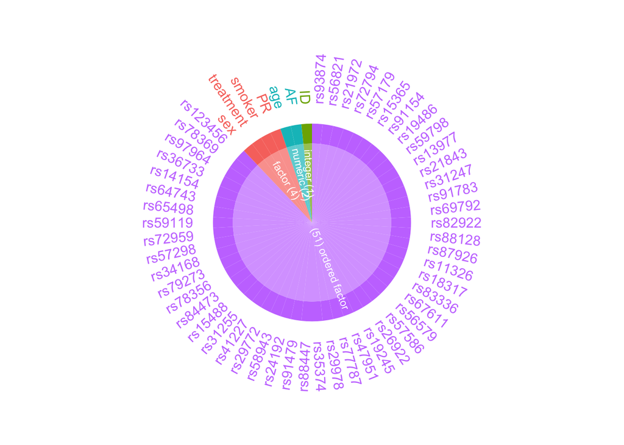

```r
# Variable Types Overview
inspect_types(df) |> show_plot()
```

```r
# Frequency distributions of the categorical variables
inspect_cat(df)
```

```
## # A tibble: 55 × 5
##    col_name   cnt common common_pcnt levels
##    <chr>    <int> <chr>        <dbl> <named list>
##  1 PR           2 yes             51 <tibble [2 × 3]>
##  2 rs11326      3 1               49 <tibble [3 × 3]>
##  3 rs123456     1 0              100 <tibble [1 × 3]>
##  4 rs13977      3 1               50 <tibble [3 × 3]>
##  5 rs14154      3 1               57 <tibble [3 × 3]>
##  6 rs15365      3 1               47 <tibble [3 × 3]>
##  7 rs15488      3 1               49 <tibble [3 × 3]>
##  8 rs18317      3 1               54 <tibble [3 × 3]>
##  9 rs19245      3 1               53 <tibble [3 × 3]>
## 10 rs19486      3 1               41 <tibble [3 × 3]>
## # ℹ 45 more rows
```

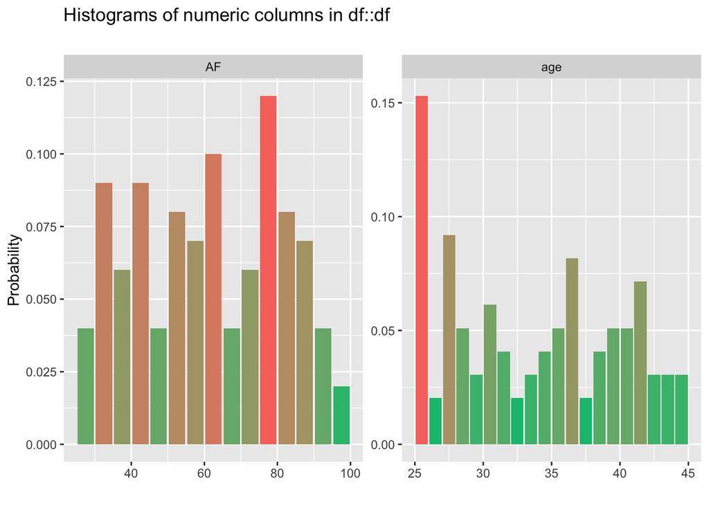

```r
# Distributions of the continuous variables
df |> select(-ID) |> inspect_num() |> show_plot()
```

The types plot now shows the expected structure: 55 factor variables (including the SNP columns as ordered factors) and 3 numeric variables (`ID`, `age`, `AF`), confirming that all conversions were applied correctly.

Basic Statistical Summary:

```r
key_vars <- c("ID", "age", "sex", "treatment", "AF", "PR")

cat("Dimensions:", nrow(df), "x", ncol(df), "\n\n")
```

```
## Dimensions: 100 x 58
```

```r
cat("Missing values per key variable:\n")
```

```
## Missing values per key variable:
```

```r
print(colSums(is.na(df[key_vars])))
```

```
##        ID       age       sex treatment        AF        PR
##         0         2         0         0         0         0
```

```r
cat("\nTreatment distribution:\n")
```

```
##
## Treatment distribution:
```

```r
print(table(df$treatment, useNA = "ifany"))
```

```
##
##  A  B  C
## 32 29 39
```

```r
cat("\nSex distribution:\n")
```

```
##
## Sex distribution:
```

```r
print(table(df$sex, useNA = "ifany"))
```

```
##
## Female   Male
##     51     49
```

```r
cat("\nPR distribution:\n")
```

```
##
## PR distribution:
```

```r
print(table(df$PR, useNA = "ifany"))
```

```
##
##  no yes
##  49  51
```

```r
cat("\nAF summary:\n")
```

```
##
## AF summary:
```

```r
print(summary(df$AF))
```

```
##    Min. 1st Qu.  Median    Mean 3rd Qu.    Max.
##   26.02   43.60   61.06   61.32   77.90   95.99
```

```r
cat("\nAge summary:\n")
```

```
##
## Age summary:
```

```r
print(summary(df$age))
```

```
##    Min. 1st Qu.  Median    Mean 3rd Qu.    Max.    NA's
##   25.00   28.00   34.50   34.16   40.00   45.00       2
```

The cleaned dataset contains 100 participants across 58 variables. Only `age` has missing values (n = 2). Treatment groups are reasonably balanced (A: 32, B: 29, C: 39), as is sex (Female: 51, Male: 49) and PR outcome (no: 49, yes: 51). AF ranges from 26.02 to 95.99 with a mean of 61.32 (median: 61.06), age ranges from 25 to 45 with a mean of 34.16.

## · Save cleaned data

```r
write.csv(df, here("data", "FITFR_clean.csv"), row.names = FALSE, na = "")
cat("Saved to", here("data", "FITFR_clean.csv"))
```

```
## Saved to /Users/l_17/Documents/⭐️Honours Degree⭐️/2026 SP2 STAT 4001 Topics in Data Science A/karls-analysis/data/FITFR_clean.csv
```

# EDA

EDA = **Exploratory Data Analysis**

This involves ‘getting to know’ the data before formal modelling begins—examining **what the data looks like**, **whether there are any missing values**, and **what relationships exist between variables**.

## · Missing values

Missing data were assessed across all variables to determine whether any imputation or case exclusion would be required prior to modelling.

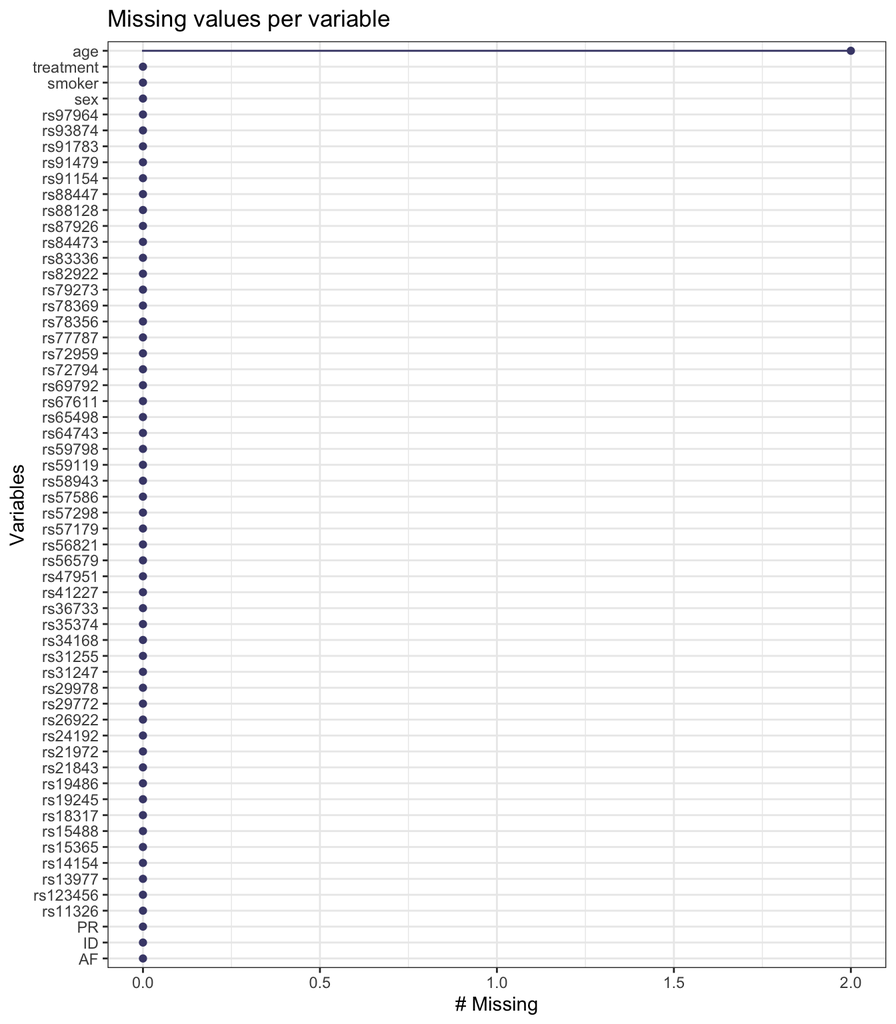

```r
gg_miss_var(df) +
  labs(title = "Missing values per variable") +
  theme_bw()
```

Only `age` contains missing values, with 2 observations recorded as sentinel value −99 and subsequently recoded to `NA` during cleaning. All other variables are complete, so no imputation is necessary.

## · Overview summary

To obtain an overview of the dataset’s structure and the distribution of key variables, we apply `skim()` across the cleaned data frame.

```r
skim(df)
```

Data summary

| Name | df |
| --- | --- |
| Number of rows | 100 |
| Number of columns | 58 |
| _______________________ |  |
| Column type frequency: |  |
| factor | 55 |
| numeric | 3 |
| ________________________ |  |
| Group variables | None |

**Variable type: factor**

| skim_variable | n_missing | complete_rate | ordered | n_unique | top_counts |
| --- | --- | --- | --- | --- | --- |
| sex | 0 | 1 | FALSE | 2 | Fem: 51, Mal: 49 |
| treatment | 0 | 1 | FALSE | 3 | C: 39, A: 32, B: 29 |
| smoker | 0 | 1 | FALSE | 1 | N: 100 |
| rs93874 | 0 | 1 | TRUE | 3 | 1: 46, 0: 30, 2: 24 |
| rs56821 | 0 | 1 | TRUE | 3 | 1: 57, 0: 25, 2: 18 |
| rs21972 | 0 | 1 | TRUE | 3 | 1: 46, 0: 32, 2: 22 |
| rs72794 | 0 | 1 | TRUE | 3 | 1: 47, 0: 28, 2: 25 |
| rs57179 | 0 | 1 | TRUE | 3 | 1: 39, 0: 37, 2: 24 |
| rs15365 | 0 | 1 | TRUE | 3 | 1: 47, 0: 27, 2: 26 |
| rs91154 | 0 | 1 | TRUE | 3 | 1: 54, 0: 25, 2: 21 |
| rs19486 | 0 | 1 | TRUE | 3 | 1: 41, 0: 31, 2: 28 |
| rs59798 | 0 | 1 | TRUE | 3 | 1: 42, 0: 34, 2: 24 |
| rs13977 | 0 | 1 | TRUE | 3 | 1: 50, 0: 26, 2: 24 |
| rs21843 | 0 | 1 | TRUE | 3 | 1: 42, 0: 32, 2: 26 |
| rs31247 | 0 | 1 | TRUE | 3 | 1: 44, 0: 30, 2: 26 |
| rs91783 | 0 | 1 | TRUE | 3 | 1: 53, 0: 27, 2: 20 |
| rs69792 | 0 | 1 | TRUE | 3 | 1: 44, 0: 30, 2: 26 |
| rs82922 | 0 | 1 | TRUE | 3 | 1: 43, 0: 30, 2: 27 |
| rs88128 | 0 | 1 | TRUE | 3 | 1: 45, 0: 32, 2: 23 |
| rs87926 | 0 | 1 | TRUE | 3 | 1: 62, 0: 20, 2: 18 |
| rs11326 | 0 | 1 | TRUE | 3 | 1: 49, 0: 32, 2: 19 |
| rs18317 | 0 | 1 | TRUE | 3 | 1: 54, 0: 25, 2: 21 |
| rs83336 | 0 | 1 | TRUE | 3 | 1: 49, 0: 28, 2: 23 |
| rs67611 | 0 | 1 | TRUE | 3 | 1: 48, 0: 30, 2: 22 |
| rs56579 | 0 | 1 | TRUE | 3 | 1: 64, 0: 20, 2: 16 |
| rs57586 | 0 | 1 | TRUE | 3 | 1: 50, 0: 25, 2: 25 |
| rs26922 | 0 | 1 | TRUE | 3 | 1: 51, 0: 27, 2: 22 |
| rs19245 | 0 | 1 | TRUE | 3 | 1: 53, 0: 25, 2: 22 |
| rs47951 | 0 | 1 | TRUE | 3 | 1: 48, 0: 31, 2: 21 |
| rs77787 | 0 | 1 | TRUE | 3 | 1: 48, 0: 29, 2: 23 |
| rs29978 | 0 | 1 | TRUE | 3 | 1: 50, 0: 28, 2: 22 |
| rs35374 | 0 | 1 | TRUE | 3 | 1: 48, 0: 27, 2: 25 |
| rs88447 | 0 | 1 | TRUE | 3 | 1: 46, 0: 27, 2: 27 |
| rs91479 | 0 | 1 | TRUE | 3 | 1: 43, 0: 29, 2: 28 |
| rs24192 | 0 | 1 | TRUE | 3 | 1: 54, 0: 25, 2: 21 |
| rs58943 | 0 | 1 | TRUE | 3 | 1: 48, 0: 28, 2: 24 |
| rs29772 | 0 | 1 | TRUE | 3 | 1: 43, 0: 33, 2: 24 |
| rs41227 | 0 | 1 | TRUE | 3 | 1: 48, 0: 29, 2: 23 |
| rs31255 | 0 | 1 | TRUE | 3 | 1: 57, 0: 27, 2: 16 |
| rs15488 | 0 | 1 | TRUE | 3 | 1: 49, 0: 26, 2: 25 |
| rs84473 | 0 | 1 | TRUE | 3 | 1: 48, 0: 29, 2: 23 |
| rs78356 | 0 | 1 | TRUE | 3 | 1: 44, 0: 29, 2: 27 |
| rs79273 | 0 | 1 | TRUE | 3 | 1: 43, 0: 30, 2: 27 |
| rs34168 | 0 | 1 | TRUE | 3 | 1: 44, 0: 29, 2: 27 |
| rs57298 | 0 | 1 | TRUE | 3 | 1: 55, 0: 25, 2: 20 |
| rs72959 | 0 | 1 | TRUE | 3 | 1: 52, 0: 25, 2: 23 |
| rs59119 | 0 | 1 | TRUE | 3 | 1: 50, 0: 27, 2: 23 |
| rs65498 | 0 | 1 | TRUE | 3 | 1: 55, 0: 26, 2: 19 |
| rs64743 | 0 | 1 | TRUE | 3 | 1: 45, 0: 34, 2: 21 |
| rs14154 | 0 | 1 | TRUE | 3 | 1: 57, 0: 24, 2: 19 |
| rs36733 | 0 | 1 | TRUE | 3 | 1: 51, 0: 25, 2: 24 |
| rs97964 | 0 | 1 | TRUE | 3 | 1: 48, 0: 27, 2: 25 |
| rs78369 | 0 | 1 | TRUE | 3 | 1: 53, 0: 28, 2: 19 |
| rs123456 | 0 | 1 | TRUE | 1 | 0: 100, 1: 0, 2: 0 |
| PR | 0 | 1 | FALSE | 2 | yes: 51, no: 49 |

**Variable type: numeric**

| skim_variable | n_missing | complete_rate | mean | sd | p0 | p25 | p50 | p75 | p100 | hist |
| --- | --- | --- | --- | --- | --- | --- | --- | --- | --- | --- |
| ID | 0 | 1.00 | 50.50 | 29.01 | 1.00 | 25.75 | 50.50 | 75.25 | 100.00 | ▇▇▇▇▇ |
| age | 2 | 0.98 | 34.16 | 6.23 | 25.00 | 28.00 | 34.50 | 40.00 | 45.00 | ▇▃▅▅▅ |
| AF | 0 | 1.00 | 61.32 | 19.81 | 26.02 | 43.60 | 61.06 | 77.90 | 95.99 | ▆▆▇▇▇ |

```r
key_vars <- c("age", "sex", "treatment", "AF", "PR")

df |>
  select(all_of(key_vars)) |>
  summarise(across(
    where(is.numeric),
    list(
      mean = ~ round(mean(.x, na.rm = TRUE), 2),
      sd   = ~ round(sd(.x, na.rm = TRUE), 2),
      min  = ~ round(min(.x, na.rm = TRUE), 2),
      max  = ~ round(max(.x, na.rm = TRUE), 2),
      missing = ~ sum(is.na(.x))
    )
  ))
```

```
## # A tibble: 1 × 10
##   age_mean age_sd age_min age_max age_missing AF_mean AF_sd AF_min AF_max
##      <dbl>  <dbl>   <dbl>   <dbl>       <int>   <dbl> <dbl>  <dbl>  <dbl>
## 1     34.2   6.23      25      45           2    61.3  19.8   26.0   96.0
## # ℹ 1 more variable: AF_missing <int>
```

```r
# Categorical variables
df |>
  select(all_of(key_vars)) |>
  select(where(is.factor)) |>
  pivot_longer(everything(), names_to = "variable", values_to = "value") |>
  group_by(variable, value) |>
  summarise(n = n(), .groups = "drop") |>
  mutate(percent = round(n / sum(n) * 100, 1), .by = variable)
```

```
## # A tibble: 7 × 4
##   variable  value      n percent
##   <chr>     <fct>  <int>   <dbl>
## 1 PR        no        49      49
## 2 PR        yes       51      51
## 3 sex       Female    51      51
## 4 sex       Male      49      49
## 5 treatment A         32      32
## 6 treatment B         29      29
## 7 treatment C         39      39
```

The dataset contains 100 participants and 58 columns, comprising 55 factor variables and 3 numeric variables. Age is the only variable with missing values (n = 2, complete rate = 0.98), with a mean of 34.2 years (SD = 6.2). AF has no missing values, with a mean of 61.3 (SD = 19.8). Among the categorical variables, sex is approximately balanced (Female: 51, Male: 49), and treatment groups are reasonably well-distributed (C: 39, A: 32, B: 29). All participants are non-smokers, confirming that smoking status carries no variation and will be excluded from modelling. The SNP variables are fully observed and encoded as ordered factors with three levels (0, 1, 2), with heterozygous genotypes (dosage = 1) being the most common across most loci.

## · Distribution of variables

To understand the structure of the data, we examine the distribution of all variables, separating continuous variables from categorical ones.

### - Continuous variables

The dataset contains two continuous variables of interest: `AF` (the primary outcome) and `age` (a potential covariate).

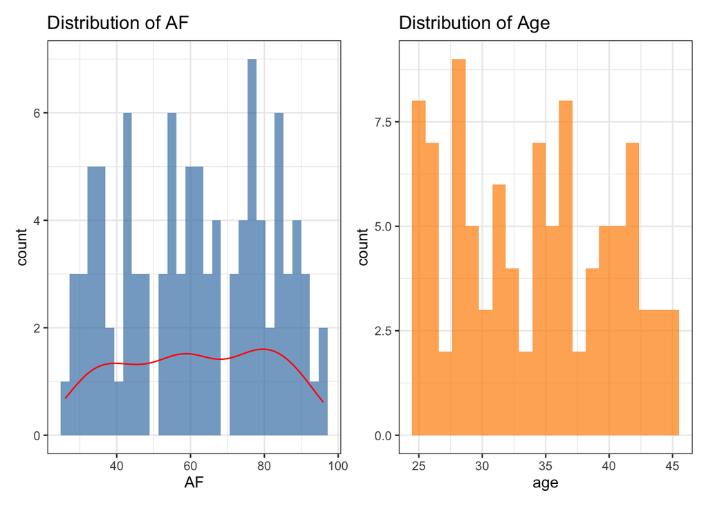

```r
# AF Distribution
p1 <- ggplot(df, aes(x = AF)) +
  geom_histogram(bins = 30, fill = "steelblue", alpha = 0.7) +
  geom_density(aes(y = after_stat(count)), colour = "red") +
  labs(title = "Distribution of AF") +
  theme_bw()

# Age Distribution
p2 <- ggplot(df, aes(x = age)) +
  geom_histogram(bins = 20, fill = "darkorange", alpha = 0.7) +
  labs(title = "Distribution of Age") +
  theme_bw()

p1 + p2
```

According to the distribution plots above, AF is roughly uniformly distributed across its range of approximately 26 to 96, with no strong skew or obvious outliers. Age is similarly spread between 25 and 45, with a slight concentration of participants in the late 20s, consistent with the mean of 34.2 years reported in the summary above.

### - Categorical variables

The categorical variables include `treatment` (the primary predictor, with three levels: A, B, C, `sex`, and `PR` (the binary outcome).

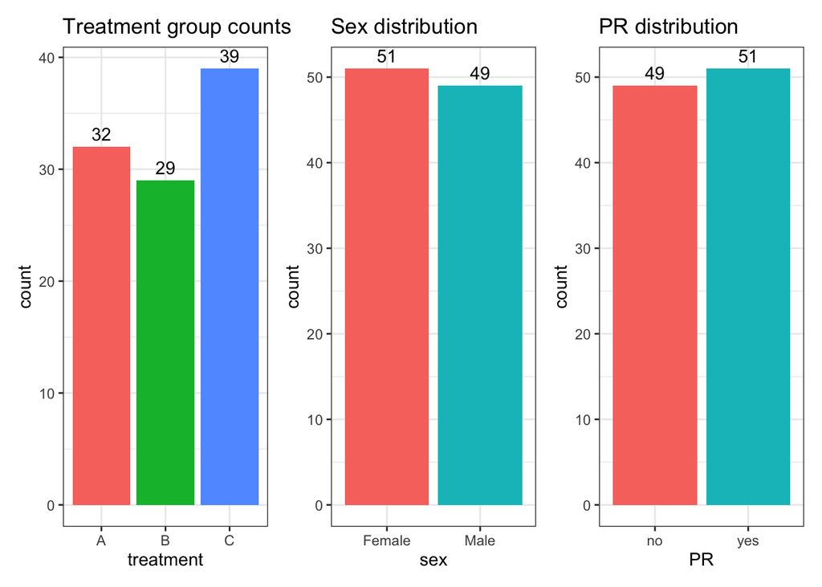

```r
p3 <- ggplot(df, aes(x = treatment, fill = treatment)) +
  geom_bar() +
  geom_text(stat = "count", aes(label = after_stat(count)), vjust = -0.5) +
  theme_bw() + theme(legend.position = "none") +
  labs(title = "Treatment group counts")

p4 <- ggplot(df, aes(x = sex, fill = sex)) +
  geom_bar() +
  geom_text(stat = "count", aes(label = after_stat(count)), vjust = -0.5) +
  theme_bw() + theme(legend.position = "none") +
  labs(title = "Sex distribution")

p5 <- ggplot(df, aes(x = PR, fill = PR)) +
  geom_bar() +
  geom_text(stat = "count", aes(label = after_stat(count)), vjust = -0.5) +
  theme_bw() + theme(legend.position = "none") +
  labs(title = "PR distribution")

p3 + p4 + p5
```

According to the distribution plots above, treatment group C has slightly more participants (n = 39) compared to A (n = 32) and B (n = 29). Sex is nearly equal between Female (n = 51) and Male (n = 49). The PR outcome is also evenly split (no: 49, yes: 51), indicating no class imbalance issue for binary modelling.

## · Descriptive statistics by treatment group

To compare the distribution of key variables across treatment groups, we generate a Table 1 stratified by treatment.

```r
vars     <- c("age", "sex", "AF", "PR")
cat_vars <- c("sex", "PR")

tbl <- CreateTableOne(
  vars       = vars,
  strata     = "treatment",
  data       = df,
  factorVars = cat_vars
)

print(tbl, showAllLevels = TRUE, quote = FALSE, noSpaces = TRUE)
```

```
##                  Stratified by treatment
##                   level  A            B             C             p      test
##   n                      32           29            39
##   age (mean (SD))        34.34 (6.12) 36.32 (5.68)  32.42 (6.34)  0.040
##   sex (%)         Female 15 (46.9)    17 (58.6)     19 (48.7)     0.615
##                   Male   17 (53.1)    12 (41.4)     20 (51.3)
##   AF (mean (SD))         37.53 (6.37) 76.93 (11.22) 69.24 (13.00) <0.001
##   PR (%)          no     15 (46.9)    10 (34.5)     24 (61.5)     0.084
##                   yes    17 (53.1)    19 (65.5)     15 (38.5)
```

Treatment groups differ significantly in AF (p < 0.001), with group B having the highest mean AF (76.93, SD = 11.22), followed by group C (69.24, SD = 13.00) and group A (37.53, SD = 6.37), suggesting a strong treatment effect. Age also differs marginally across groups (p = 0.040), with group B being slightly older on average (36.32 years). Sex distribution (p = 0.615) and PR rate (p = 0.084) do not differ significantly across treatment groups.

```r
kruskal.test(AF ~ treatment, data = df)
```

```
##
##  Kruskal-Wallis rank sum test
##
## data:  AF by treatment
## Kruskal-Wallis chi-squared = 67.281, df = 2, p-value = 2.456e-15
```

## · Correlation matrix

To assess potential multicollinearity among continuous and genetic variables, we examine pairwise correlations between age, AF, and all SNP variables first using `corrplot`.

[figure not shown]

```r
snp_cols <- names(df)[str_detect(names(df), "^rs")]

cor_data <- df |>
  select(age, AF, all_of(snp_cols)) |>
  mutate(across(everything(), as.numeric)) |>
  na.omit()

corrplot(cor(cor_data),
         method = "color",
         type   = "upper",
         addCoef.col = "black",
         tl.cex = 0.7,
         number.cex = 0.6,
         title  = "Correlation Matrix: Continuous & SNP Variables",
         mar    = c(0,0,1,0))
```

The correlation matrix reveals that most SNP variables show weak pairwise correlations with each other and with age and AF, suggesting limited multicollinearity among the genetic predictors. A small number of SNP pairs show moderate correlations (|r| > 0.3), which may warrant attention during modelling.

# Primary Relationships / Plots

Having explored the structure and distribution of the data, we now examine the key relationships relevant to the research question: the effect of treatment on AF and PR, and the potential influence of covariates including age, sex, and genetic variables.

Smoking status and rs123456 are excluded from further analysis as both are zero-variance variables — all participants are non-smokers and all carry the CC genotype at rs123456, meaning neither variable can contribute any information to the model.

## Main topic: The impact of treatment on AF and PR

We first examine the primary relationship of interest — how treatment group relates to both the continuous outcome AF and the binary outcome PR.

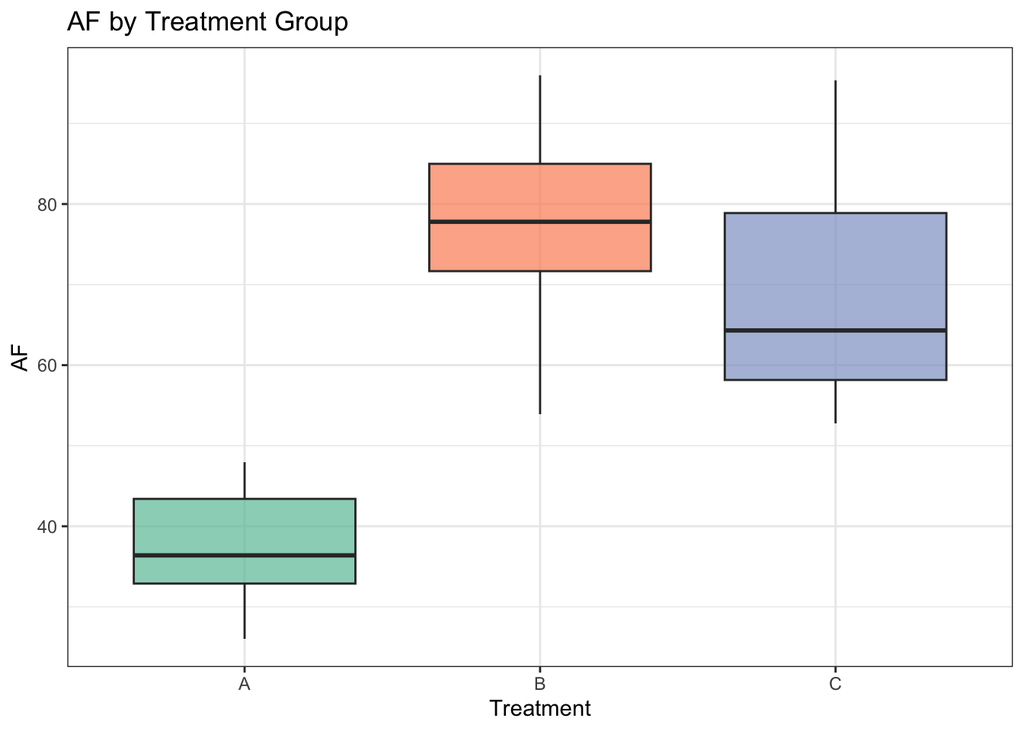

Distribution of AF by treatment group.

```r
ggplot(df, aes(x = treatment, y = AF, fill = treatment)) +
  geom_boxplot(alpha = 0.7, outlier.shape = 21) +
  scale_fill_brewer(palette = "Set2") +
  labs(title = "AF by Treatment Group", x = "Treatment", y = "AF") +
  theme_bw() +
  theme(legend.position = "none")
```

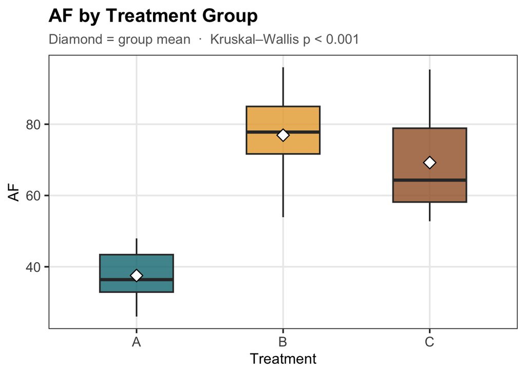

```r
ggplot(df, aes(x = treatment, y = AF, fill = treatment)) +
  geom_boxplot(alpha = 0.8, outlier.shape = 21, width = 0.5) +
  stat_summary(fun = mean, geom = "point", shape = 23,
               size = 4, fill = "white", colour = "black") +
  scale_fill_manual(values = trt_colours) +
  labs(title = "AF by Treatment Group",
       subtitle = "Diamond = group mean  ·  Kruskal–Wallis p < 0.001",
       x = "Treatment", y = "AF") +
  theme_ppt +
  theme(legend.position = "none")
```

```r
save_ppt_fig("ppt_af_by_treatment.png")
```

AF values differ substantially across treatment groups. Group B shows the highest median AF (approximately 78), followed by group C (approximately 64), while group A has considerably lower values (median approximately 37) with a much tighter distribution. The non-overlapping interquartile ranges between group A and the other two groups strongly suggest a clinically meaningful treatment effect on AF.

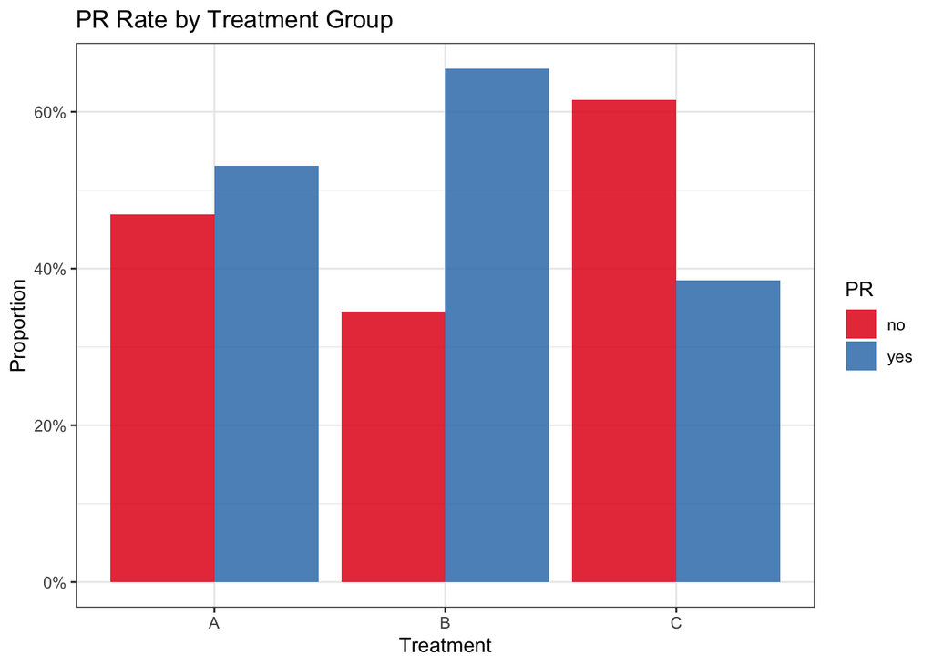

Proportion of PR by treatment group.

```r
df |>
  filter(!is.na(PR)) |>
  group_by(treatment, PR) |>
  summarise(n = n(), .groups = "drop") |>
  mutate(prop = n / sum(n), .by = treatment) |>
  ggplot(aes(x = treatment, y = prop, fill = PR)) +
  geom_col(position = "dodge", alpha = 0.85) +
  scale_fill_brewer(palette = "Set1") +
  scale_y_continuous(labels = scales::percent) +
  labs(title = "PR Rate by Treatment Group", x = "Treatment",
       y = "Proportion", fill = "PR") +
  theme_bw()
```

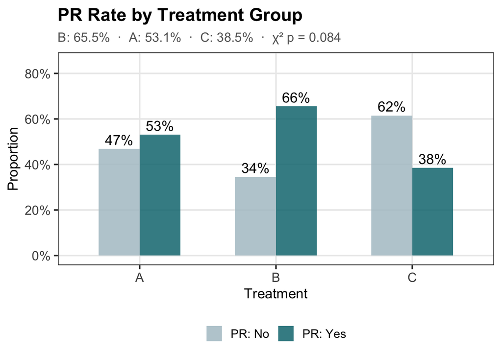

```r
df |>
  filter(!is.na(PR)) |>
  group_by(treatment, PR) |>
  summarise(n = n(), .groups = "drop") |>
  mutate(prop = n / sum(n), .by = treatment) |>
  ggplot(aes(x = treatment, y = prop, fill = PR)) +
  geom_col(position = "dodge", alpha = 0.85, width = 0.6) +
  geom_text(aes(label = percent(prop, accuracy = 1)),
            position = position_dodge(0.6), vjust = -0.4, size = 5) +
  scale_fill_manual(values = c(no = "#B0C4CC", yes = "#0D7680"),
                    labels = c("PR: No", "PR: Yes")) +
  scale_y_continuous(labels = percent, limits = c(0, 0.85)) +
  labs(title = "PR Rate by Treatment Group",
       subtitle = "B: 65.5%  ·  A: 53.1%  ·  C: 38.5%  ·  χ² p = 0.084",
       x = "Treatment", y = "Proportion", fill = NULL) +
  theme_ppt
```

```r
save_ppt_fig("ppt_pr_by_treatment.png")
```

Treatment group B has the highest PR rate (approximately 66%), followed by group A (approximately 53%), while group C has the lowest PR rate (approximately 38%) despite having the second highest AF values. This suggests that the relationship between treatment, AF, and PR is not straightforward, and that treatment C may produce higher AF values without necessarily translating to a PR.

## Sub-topic: The impact of Age on AF and PR

Age is a potential covariate that may confound the relationship between treatment and the outcomes. We examine whether age is associated with either AF or PR before formal modelling.

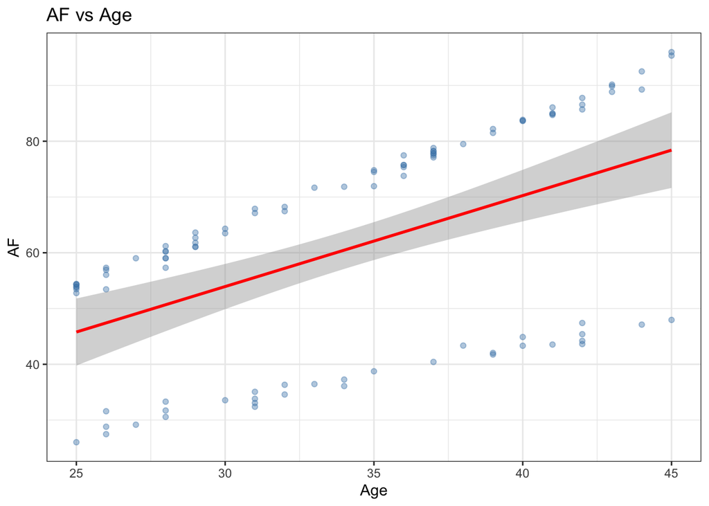

Relationship between age and AF.

```r
ggplot(df, aes(x = age, y = AF)) +
  geom_point(alpha = 0.4, colour = "steelblue") +
  geom_smooth(method = "lm", se = TRUE, colour = "red") +
  labs(title = "AF vs Age", x = "Age", y = "AF") +
  theme_bw()
```

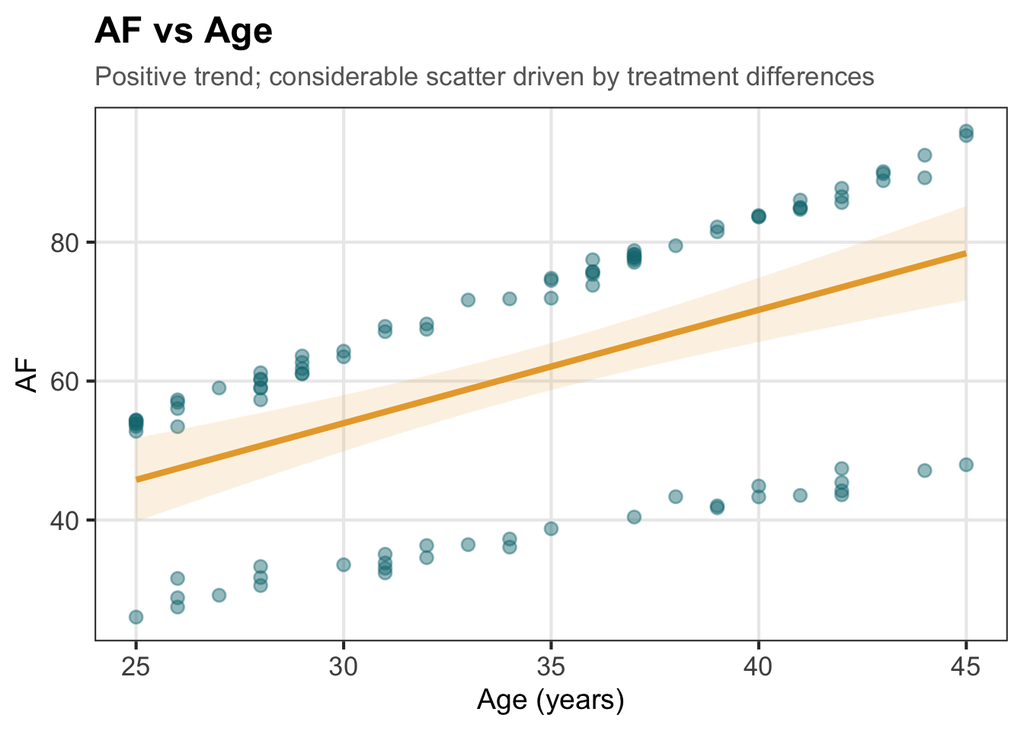

```r
ggplot(df, aes(x = age, y = AF)) +
  geom_point(alpha = 0.45, colour = "#0D7680", size = 2.5) +
  geom_smooth(method = "lm", se = TRUE, colour = "#E8A838", fill = "#E8A838", alpha = 0.15) +
  labs(title = "AF vs Age",
       subtitle = "Positive trend; considerable scatter driven by treatment differences",
       x = "Age (years)", y = "AF") +
  theme_ppt
```

```r
save_ppt_fig("ppt_af_vs_age.png", width = 8, height = 6)
```

There is a positive linear relationship between age and AF, with older participants tending to have higher AF values. However, there is considerable scatter around the regression line, suggesting that age alone does not fully explain the variation in AF. This indicates that age may act as a covariate worth adjusting for in formal modelling, but treatment group is likely the dominant predictor.

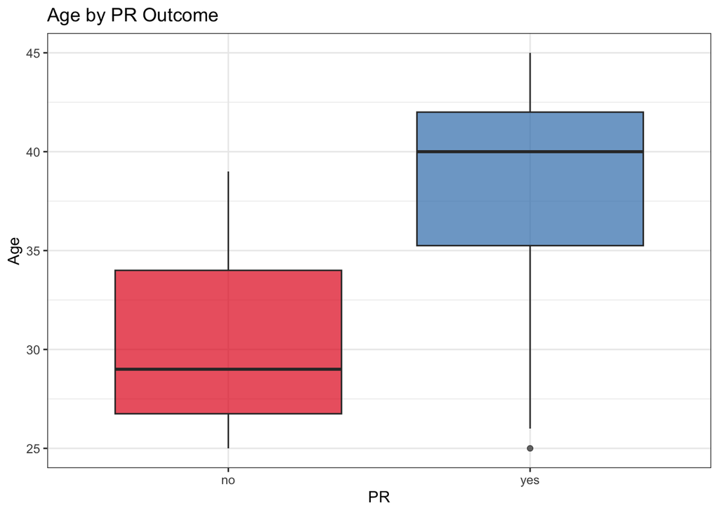

Age distribution by PR outcome.

```r
ggplot(df |> filter(!is.na(PR)), aes(x = PR, y = age, fill = PR)) +
  geom_boxplot(alpha = 0.7) +
  scale_fill_brewer(palette = "Set1") +
  labs(title = "Age by PR Outcome", x = "PR", y = "Age") +
  theme_bw() +
  theme(legend.position = "none")
```

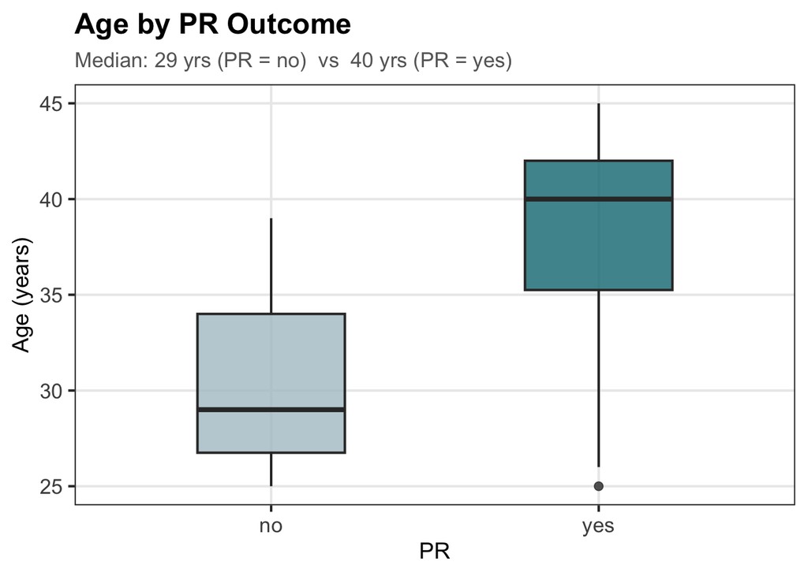

```r
ggplot(df |> filter(!is.na(PR)), aes(x = PR, y = age, fill = PR)) +
  geom_boxplot(alpha = 0.8, width = 0.45) +
  scale_fill_manual(values = c(no = "#B0C4CC", yes = "#0D7680")) +
  labs(title = "Age by PR Outcome",
       subtitle = "Median: 29 yrs (PR = no)  vs  40 yrs (PR = yes)",
       x = "PR", y = "Age (years)") +
  theme_ppt +
  theme(legend.position = "none")
```

```r
save_ppt_fig("ppt_age_by_pr.png", width = 8, height = 6)
```

Participants with a PR (PR = yes) tend to be considerably older (median approximately 40 years) compared to those without (median approximately 29 years), with minimal overlap between the interquartile ranges of the two groups. This suggests that age is strongly associated with PR outcome and should be included as a covariate in any model predicting PR.

## Sub-topic: The impact of sex on AF and PR

We next examine whether sex is associated with AF or PR, as it may act as a confounding variable in the relationship between treatment and the outcomes.

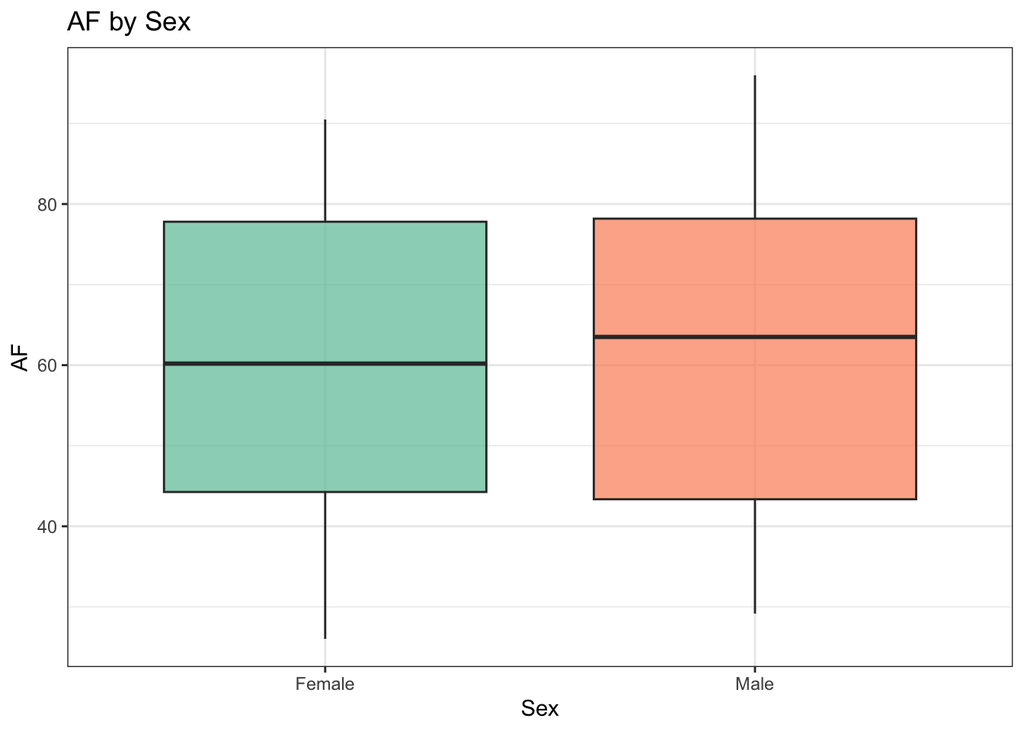

AF by sex.

```r
ggplot(df, aes(x = sex, y = AF, fill = sex)) +
  geom_boxplot(alpha = 0.7) +
  scale_fill_brewer(palette = "Set2") +
  labs(title = "AF by Sex", x = "Sex", y = "AF") +
  theme_bw() +
  theme(legend.position = "none")
```

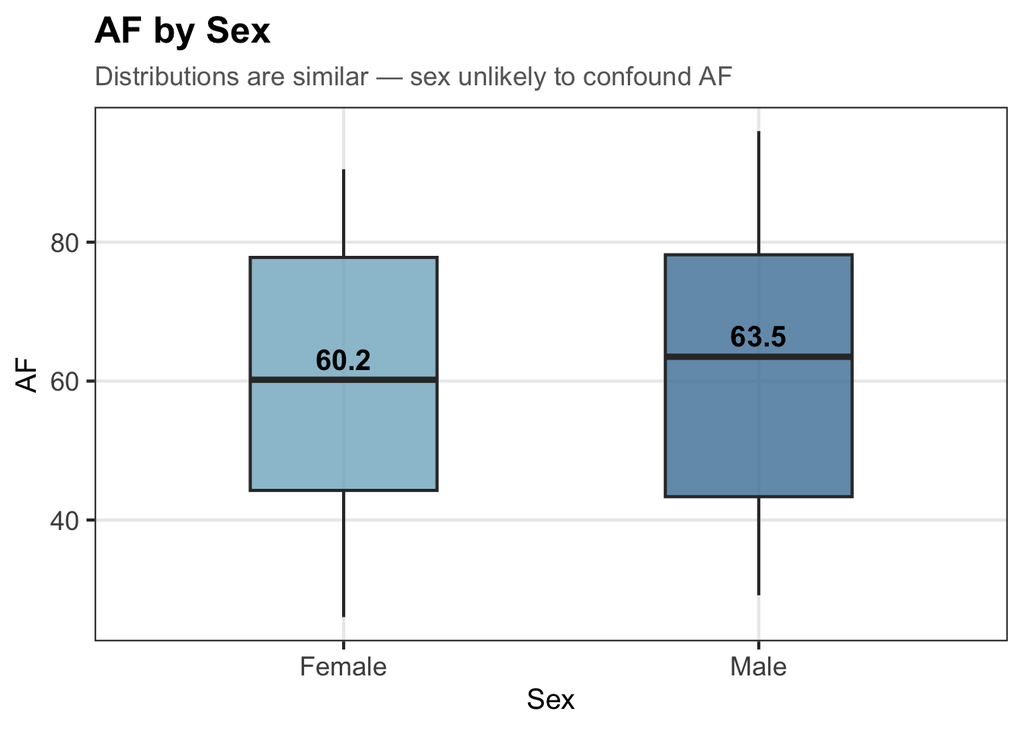

```r
ggplot(df, aes(x = sex, y = AF, fill = sex)) +
  geom_boxplot(alpha = 0.8, width = 0.45) +
  stat_summary(
    fun = median,
    geom = "text",
    aes(label = round(after_stat(y), 1)),
    vjust = -0.5,
    size = 5,
    fontface = "bold"
  ) +
  scale_fill_manual(values = c(Female = "#7FB3C8", Male = "#4A7FA5")) +
  labs(title = "AF by Sex",
       subtitle = "Distributions are similar — sex unlikely to confound AF",
       x = "Sex", y = "AF") +
  theme_ppt +
  theme(legend.position = "none")
```

```r
save_ppt_fig("ppt_af_by_sex.png", width = 8, height = 6)
```

AF distributions are similar between females and males, with both groups having comparable medians (approximately 60 and 63 respectively) and largely overlapping interquartile ranges. This suggests that sex has little marginal association with AF, though it may still be worth adjusting for in formal modelling.

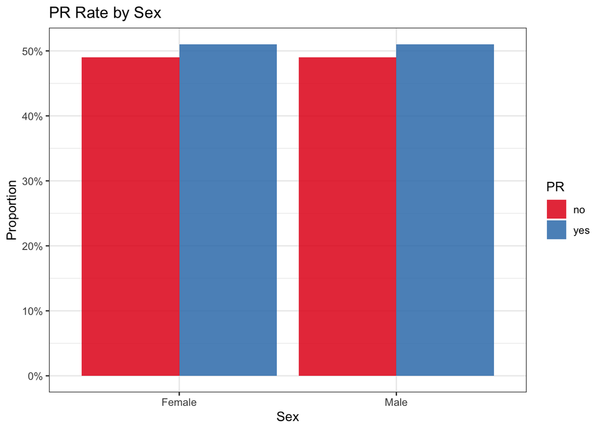

PR rate by sex.

```r
df |>
  filter(!is.na(PR), !is.na(sex)) |>
  group_by(sex, PR) |>
  summarise(n = n(), .groups = "drop") |>
  mutate(prop = n / sum(n), .by = sex) |>
  ggplot(aes(x = sex, y = prop, fill = PR)) +
  geom_col(position = "dodge", alpha = 0.85) +
  scale_fill_brewer(palette = "Set1") +
  scale_y_continuous(labels = scales::percent) +
  labs(title = "PR Rate by Sex", x = "Sex", y = "Proportion", fill = "PR") +
  theme_bw()
```

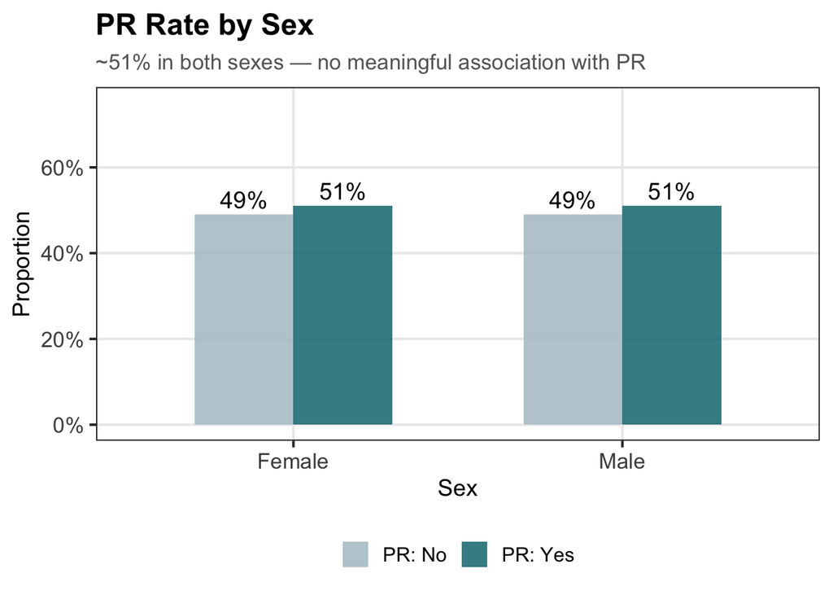

```r
df |>
  filter(!is.na(PR), !is.na(sex)) |>
  group_by(sex, PR) |>
  summarise(n = n(), .groups = "drop") |>
  mutate(prop = n / sum(n), .by = sex) |>
  ggplot(aes(x = sex, y = prop, fill = PR)) +
  geom_col(position = "dodge", alpha = 0.85, width = 0.6) +
  geom_text(aes(label = percent(prop, accuracy = 1)),
            position = position_dodge(0.6), vjust = -0.4, size = 5) +
  scale_fill_manual(values = c(no = "#B0C4CC", yes = "#0D7680"),
                    labels = c("PR: No", "PR: Yes")) +
  scale_y_continuous(labels = percent, limits = c(0, 0.75)) +
  labs(title = "PR Rate by Sex",
       subtitle = "~51% in both sexes — no meaningful association with PR",
       x = "Sex", y = "Proportion", fill = NULL) +
  theme_ppt
```

```r
save_ppt_fig("ppt_pr_by_sex.png", width = 8, height = 6)
```

The PR rate is virtually identical between females and males (both approximately 51% positive), indicating that sex has no meaningful association with PR in this dataset. Sex is therefore unlikely to be an important covariate for the PR outcome in formal modelling.

## Sub-topic: The effect of SNP on AF and PR

Before examining SNP–outcome associations, we first look at how genotypes are distributed across dosage groups. Most SNPs in this sample are dominated by heterozygous carriers (dosage = 1), with relatively few participants in the homozygous alternate group (dosage = 2) — meaning effect estimates at dosage 2 should be interpreted with caution due to small cell sizes.

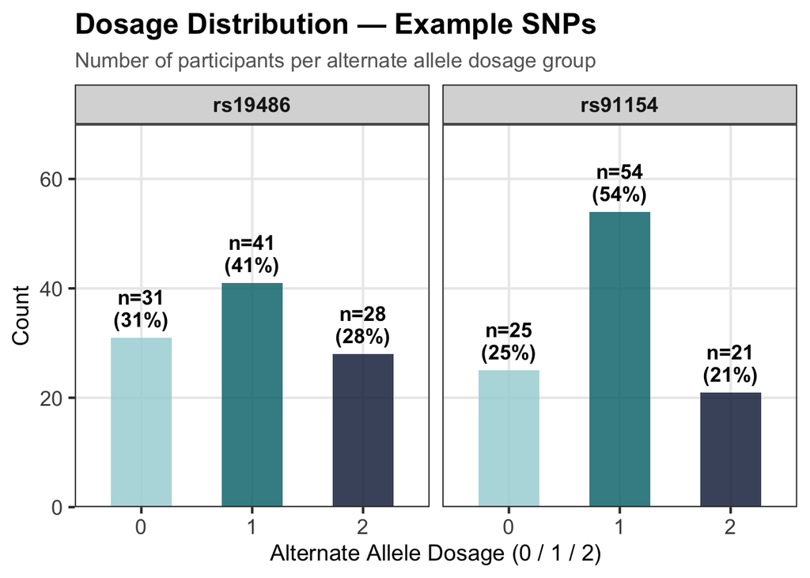

```r
# Select two representative SNPs to illustrate the dosage distribution
example_snps <- c("rs19486", "rs91154")

df |>
  select(all_of(example_snps)) |>
  pivot_longer(everything(), names_to = "SNP", values_to = "dosage") |>
  filter(!is.na(dosage)) |>
  group_by(SNP, dosage) |>
  summarise(n = n(), .groups = "drop") |>
  mutate(pct = n / sum(n), .by = SNP) |>
  ggplot(aes(x = dosage, y = n, fill = dosage)) +
  geom_col(width = 0.55, alpha = 0.85) +
  geom_text(aes(label = paste0("n=", n, "\n(", round(pct*100), "%)")),
            vjust = -0.3, size = 4.5, fontface = "bold", lineheight = 0.9) +
  scale_fill_manual(values = c("0" = "#A8D5D9", "1" = "#0D7680", "2" = "#1B2B4B")) +
  scale_y_continuous(limits = c(0, 70), expand = c(0, 0)) +
  facet_wrap(~ SNP) +
  labs(
    title    = "Dosage Distribution — Example SNPs",
    subtitle = "Number of participants per alternate allele dosage group",
    x        = "Alternate Allele Dosage (0 / 1 / 2)",
    y        = "Count"
  ) +
  theme_ppt +
  theme(legend.position = "none")
```

```r
save_ppt_fig("ppt_snp_dosage_example.png", width = 8, height = 7)
```

Finally, we examine whether genetic variation, as captured by the SNP variables, is associated with AF or PR. Each SNP is encoded under an additive model with dosage values of 0, 1, or 2 representing the number of alternate alleles carried by each participant.

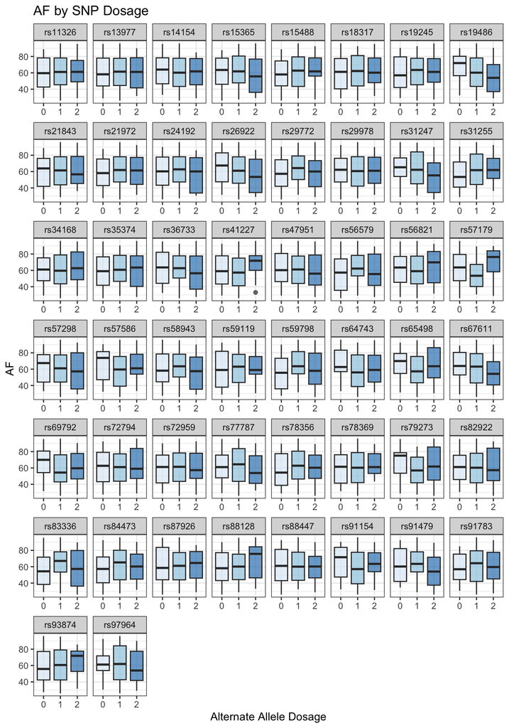

AF distribution by SNP dosage for each SNP.

```r
snp_cols <- names(df)[str_detect(names(df), "^rs") &
                        names(df) != "rs123456"]  # 排除零方差列

df |>
  select(AF, all_of(snp_cols)) |>
  pivot_longer(-AF, names_to = "SNP", values_to = "dosage") |>
  filter(!is.na(dosage)) |>
  ggplot(aes(x = dosage, y = AF, fill = dosage)) +
  geom_boxplot(alpha = 0.7) +
  facet_wrap(~ SNP, scales = "free_x") +
  scale_fill_brewer(palette = "Blues") +
  labs(title = "AF by SNP Dosage", x = "Alternate Allele Dosage",
       y = "AF") +
  theme_bw() +
  theme(legend.position = "none")
```

Across most SNPs, the distribution of AF appears similar across dosage groups (0, 1, 2), with largely overlapping interquartile ranges, suggesting that the majority of SNPs have little marginal association with AF. However, a small number of SNPs show modest differences across dosage groups — for example, rs88128 appear to show a trend of increasing and rs19486 showing a trend of decreasing AF with higher alternate allele dosage. These SNPs may be worth investigating further in formal modelling, though the small sample sizes within each dosage group warrant caution in interpretation.

To identify which SNPs show the strongest marginal association with AF, we computed the Spearman correlation between each SNP’s alternate allele dosage and AF across all 50 SNPs. The top 10 SNPs ranked by |r| are shown below, with the direction of association indicated by colour.

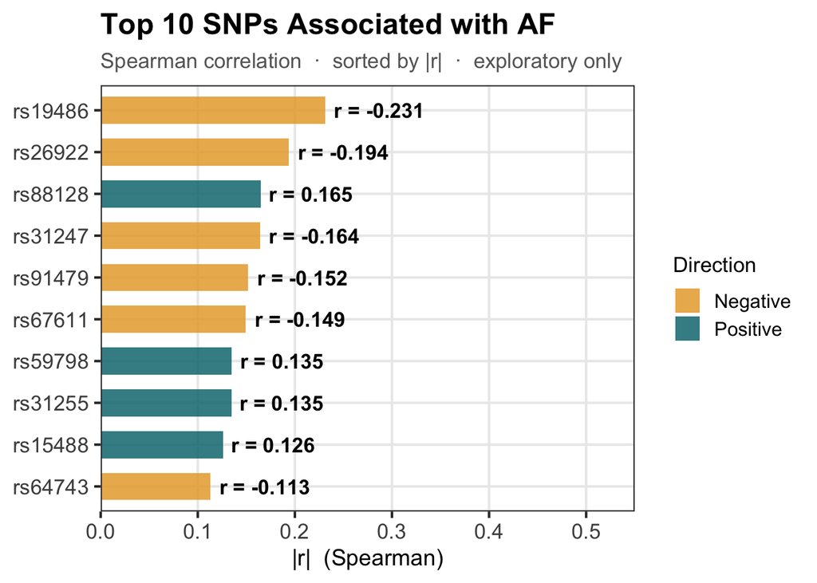

```r
snp_cols_clean <- names(df)[str_detect(names(df), "^rs") & names(df) != "rs123456"]

# Calculate the Spearman’s correlation coefficient between each SNP and AF
snp_cor_af <- tibble(
  SNP = snp_cols_clean,
  r   = sapply(snp_cols_clean, function(s) {
    cor(as.numeric(df[[s]]), df$AF, use = "complete.obs", method = "spearman")
  })
) |>
  arrange(desc(abs(r))) |>
  slice_head(n = 10) |>
  mutate(
    SNP       = fct_reorder(SNP, abs(r)),
    direction = if_else(r > 0, "Positive", "Negative")
  )

ggplot(snp_cor_af, aes(x = abs(r), y = SNP, fill = direction)) +
  geom_col(width = 0.65, alpha = 0.85) +
  geom_text(aes(label = sprintf("r = %.3f", r)),
            hjust = -0.1, size = 4.5, fontface = "bold") +
  scale_fill_manual(values = c(Positive = "#0D7680", Negative = "#E8A838")) +
  scale_x_continuous(limits = c(0, 0.55), expand = c(0, 0)) +
  labs(
    title    = "Top 10 SNPs Associated with AF",
    subtitle = "Spearman correlation  ·  sorted by |r|  ·  exploratory only",
    x        = "|r|  (Spearman)",
    y        = NULL,
    fill     = "Direction"
  ) +
  theme_ppt +
  theme(legend.position = "right")
```

```r
save_ppt_fig("ppt_snp_top10_af.png", width = 8, height = 6)
```

All top 10 correlations are weak (|r| ≤ 0.23), consistent with the expectation that individual SNPs rarely explain large proportions of variance in complex traits. rs19486 and rs26922 show the strongest negative associations with AF, while rs88128 shows the strongest positive association. These effect sizes are modest and should be interpreted cautiously — formal testing with appropriate multiple testing correction (e.g. Bonferroni or FDR) will be required before drawing any conclusions about individual SNP effects.

To complement the AF analysis, we examine whether SNP dosage is associated with PR outcome. For each SNP, the proportion of participants with PR = yes and PR = no is plotted separately for each dosage group (0, 1, 2).

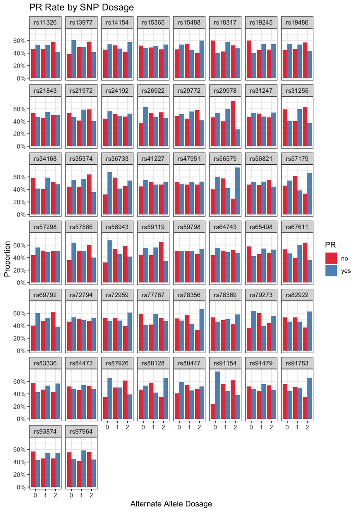

PR rate by SNP dosage for each SNP.

```r
df |>
  select(PR, all_of(snp_cols)) |>
  pivot_longer(-PR, names_to = "SNP", values_to = "dosage") |>
  filter(!is.na(dosage), !is.na(PR)) |>
  group_by(SNP, dosage, PR) |>
  summarise(n = n(), .groups = "drop") |>
  mutate(prop = n / sum(n), .by = c(SNP, dosage)) |>
  ggplot(aes(x = dosage, y = prop, fill = PR)) +
  geom_col(position = "dodge", alpha = 0.85) +
  facet_wrap(~ SNP) +
  scale_fill_brewer(palette = "Set1") +
  scale_y_continuous(labels = scales::percent) +
  labs(title = "PR Rate by SNP Dosage", x = "Alternate Allele Dosage",
       y = "Proportion", fill = "PR") +
  theme_bw()
```

Similar to the AF results, most SNPs show little variation in PR rate across dosage groups, with the proportion of positive responses remaining roughly 50/50 regardless of alternate allele dosage. A few SNPs such as rs91154 and rs58943 show more noticeable shifts in PR rate across dosage levels, which may warrant closer examination in formal modelling. Overall, the marginal effect of individual SNPs on PR appears modest at this exploratory stage.

Similarly, to identify which SNPs show the strongest marginal association with PR, we computed the Spearman correlation between each SNP’s alternate allele dosage and PR outcome (coded as 0 = no, 1 = yes) across all 50 SNPs. The top 10 SNPs ranked by |r| are shown below.

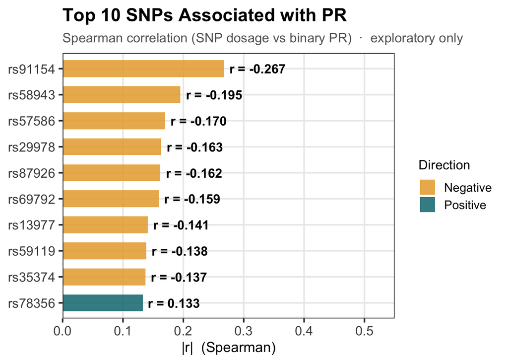

```r
# Converting PR to 0/1 values
pr_numeric <- as.numeric(df$PR) - 1  # no=0, yes=1

snp_cor_pr <- tibble(
  SNP = snp_cols_clean,
  r   = sapply(snp_cols_clean, function(s) {
    cor(as.numeric(df[[s]]), pr_numeric, use = "complete.obs", method = "spearman")
  })
) |>
  arrange(desc(abs(r))) |>
  slice_head(n = 10) |>
  mutate(
    SNP       = fct_reorder(SNP, abs(r)),
    direction = if_else(r > 0, "Positive", "Negative")
  )

ggplot(snp_cor_pr, aes(x = abs(r), y = SNP, fill = direction)) +
  geom_col(width = 0.65, alpha = 0.85) +
  geom_text(aes(label = sprintf("r = %.3f", r)),
            hjust = -0.1, size = 4.5, fontface = "bold") +
  scale_fill_manual(values = c(Positive = "#0D7680", Negative = "#E8A838")) +
  scale_x_continuous(limits = c(0, 0.55), expand = c(0, 0)) +
  labs(
    title    = "Top 10 SNPs Associated with PR",
    subtitle = "Spearman correlation (SNP dosage vs binary PR)  ·  exploratory only",
    x        = "|r|  (Spearman)",
    y        = NULL,
    fill     = "Direction"
  ) +
  theme_ppt +
  theme(legend.position = "right")
```

```r
#save_ppt_fig("ppt_snp_top10_pr.png", width = 8, height = 6)
```

rs91154 shows the strongest negative association with PR (r = −0.267), meaning higher alternate allele dosage is associated with a lower probability of PR. Nine of the top 10 SNPs show negative associations, with rs78356 being the only exception. As with AF, all correlations remain weak (|r| ≤ 0.27), and these findings are exploratory — formal testing with multiple testing correction is required before any SNP can be considered a candidate predictor of PR.

To visualise the dosage-response relationship more directly, we plot the observed PR probability at each dosage level (0, 1, 2) for the top 10 SNPs identified above. A downward trend across dosage groups would be consistent with the negative correlations observed, suggesting that carrying more alternate alleles is associated with a lower probability of PR.

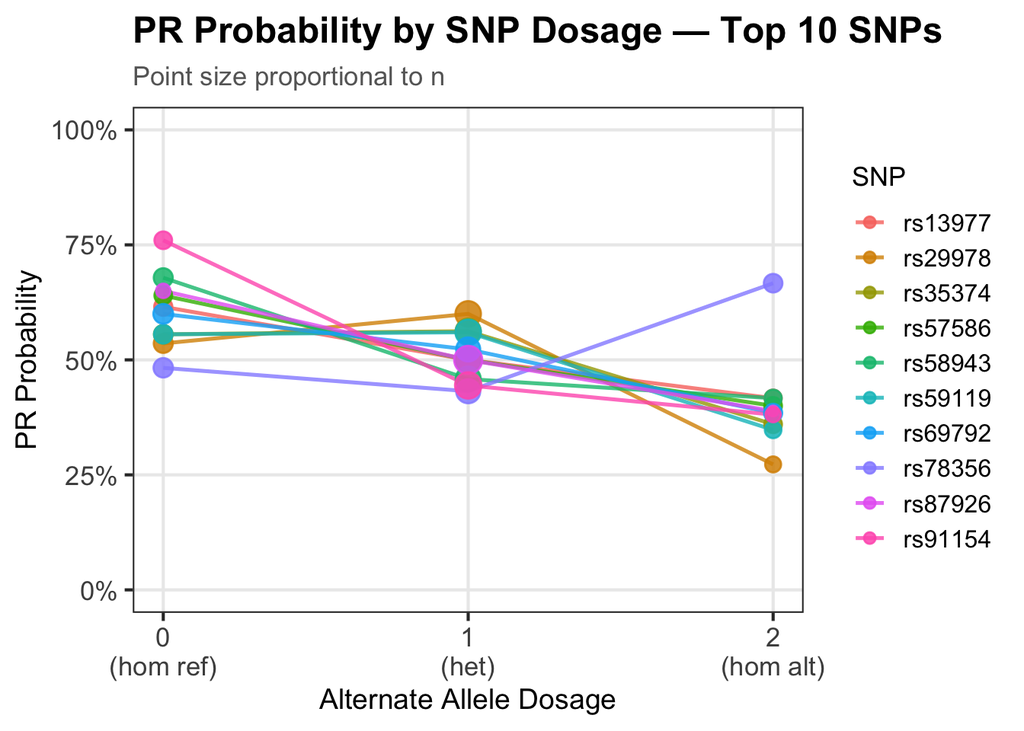

```r
# Using the top 10 PR SNPs calculated earlier
top_pr_snps <- snp_cor_pr |> pull(SNP) |> as.character()

df |>
  select(PR, all_of(top_pr_snps)) |>
  pivot_longer(-PR, names_to = "SNP", values_to = "dosage") |>
  filter(!is.na(dosage), !is.na(PR)) |>
  group_by(SNP, dosage) |>
  summarise(
    prob = mean(PR == "yes"),
    n    = n(),
    .groups = "drop"
  ) |>
  mutate(dosage = as.numeric(as.character(dosage))) |>
  ggplot(aes(x = dosage, y = prob, colour = SNP, group = SNP)) +
  geom_line(linewidth = 0.9, alpha = 0.8) +
  geom_point(aes(size = n), alpha = 0.85) +
  scale_y_continuous(labels = percent, limits = c(0, 1)) +
  scale_x_continuous(breaks = c(0, 1, 2),
                     labels = c("0\n(hom ref)", "1\n(het)", "2\n(hom alt)")) +
  scale_size_continuous(range = c(2, 6), guide = "none") +
  labs(
    title    = "PR Probability by SNP Dosage — Top 10 SNPs",
    subtitle = "Point size proportional to n",
    x        = "Alternate Allele Dosage",
    y        = "PR Probability",
    colour   = "SNP"
  ) +
  theme_ppt +
  theme(legend.position = "right")
```

```r
#save_ppt_fig("ppt_snp_dosage_pr_prob.png", width = 9.3, height = 7)
```

The majority of SNPs show a consistent downward trend from dosage 0 to dosage 2, corroborating the negative correlations observed above. rs91154 shows the steepest decline, dropping from approximately 75% PR probability at dosage 0 to around 38% at dosage 2. rs78356 is the clear exception, showing an upward trend consistent with its positive correlation. Note that dosage 2 points are based on small cell sizes for most SNPs — the apparent trends at the homozygous alternate level should be interpreted with caution until confirmed in formal modelling.

To provide a broader overview across all 50 SNPs, we plot PR probability by dosage for every SNP simultaneously, highlighting the 10 SNPs with the highest observed PR probability at any dosage level. Grey lines represent the remaining SNPs as background context.

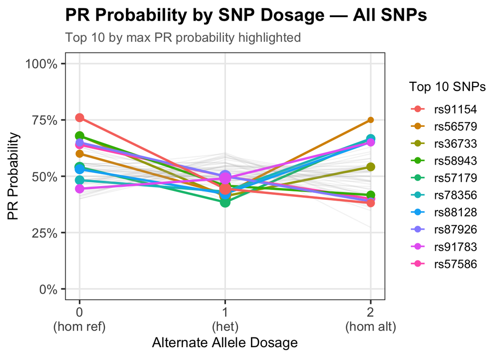

```r
snp_probs <- df |>
  select(PR, all_of(snp_cols_clean)) |>
  pivot_longer(-PR, names_to = "SNP", values_to = "dosage") |>
  filter(!is.na(dosage), !is.na(PR)) |>
  group_by(SNP, dosage) |>
  summarise(
    prob = mean(PR == "yes"),
    n    = n(),
    .groups = "drop"
  ) |>
  mutate(dosage = as.numeric(as.character(dosage)))

# Identify the top 10 SNPs with the highest probability of PR at any given dosage
top10_snps <- snp_probs |>
  group_by(SNP) |>
  summarise(max_prob = max(prob)) |>
  arrange(desc(max_prob)) |>
  slice_head(n = 10) |>
  pull(SNP)

snp_probs |>
  mutate(
    highlight = if_else(SNP %in% top10_snps, SNP, "other"),
    alpha_val = if_else(SNP %in% top10_snps, 1, 0.15),
    lwd_val   = if_else(SNP %in% top10_snps, 1.1, 0.5)
  ) |>
  ggplot(aes(x = dosage, y = prob, group = SNP,
             colour = highlight, alpha = alpha_val, linewidth = lwd_val)) +
  geom_line() +
  geom_point(data = ~ filter(., SNP %in% top10_snps),
             aes(size = n), alpha = 1) +
  scale_colour_manual(
    values = c(setNames(scales::hue_pal()(10), top10_snps), other = "grey70"),
    breaks = top10_snps   # legend: Show top 10 only
  ) +
  scale_alpha_identity() +
  scale_linewidth_identity() +
  scale_size_continuous(range = c(2, 5), guide = "none") +
  scale_y_continuous(labels = percent, limits = c(0, 1)) +
  scale_x_continuous(breaks = c(0, 1, 2),
                     labels = c("0\n(hom ref)", "1\n(het)", "2\n(hom alt)")) +
  labs(
    title    = "PR Probability by SNP Dosage — All SNPs",
    subtitle = "Top 10 by max PR probability highlighted",
    x        = "Alternate Allele Dosage",
    y        = "PR Probability",
    colour   = "Top 10 SNPs"
  ) +
  theme_ppt +
  theme(legend.position = "right")
```

```r
save_ppt_fig("ppt_snp_dosage_pr_prob_all.png", width = 9.3, height = 7)
```

Unlike the top 10 by correlation (which were predominantly negative), the top 10 by maximum PR probability show more heterogeneous patterns — some lines trend downward (e.g. rs91154), while others increase sharply at dosage 2 (e.g. rs56579, rs78356). This divergence highlights that high maximum probability does not necessarily imply a consistent dosage-response relationship. The crossing of lines at dosage 1 and the wide spread at dosage 2 again reflect the small sample sizes in the homozygous alternate group, which can produce unstable probability estimates. These SNPs warrant closer inspection in formal modelling, but no conclusions should be drawn from exploratory plots alone.